# Exercise 4 - answers

Gerko Vink

Fundamental Techniques in Data Science with R

11. **Repeat the experiment from 10 on object `y` from `Exercise4_data.RData`.**
- Plot a histogram of `y` and report on the shape of the data

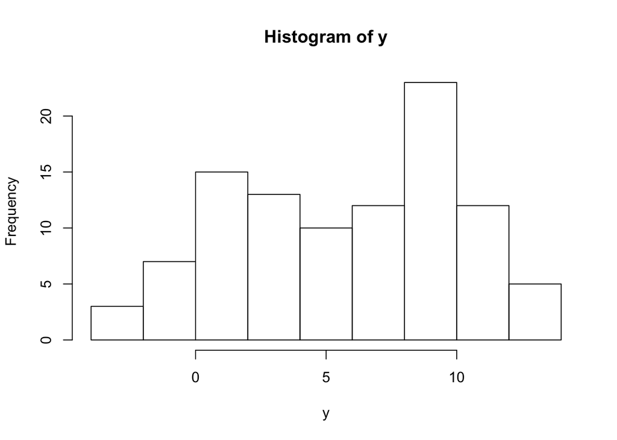

```r
hist(y)
```

- What do you think the mean is, based on the plot?

**Hard to say, the data seems to be bi-modal. Somewhere around 6? as there seems to be more mass around 10 than around 1.**

- Calculate the mean (expected value)

```r
mean(y)
```

```
## [1] 5.777224
```

- Calculate the median (the center of the distribution)

```r
median(y)
```

```
## [1] 6.12544
```

- Calculate the mode (the most observed value). Calculate the mode on rounded numbers (HINT: use `round()`).

```r
round(y) %>% table
```

```
## .
## -3 -2 -1  0  1  2  3  4  5  6  7  8  9 10 11 12 13 14
##  3  3  3  3  8  8  8  5  5  7  5  5 12 13  5  4  1  2
```

**The mode seems to be around 10**

- what do the mean, mode and median tell you about the shape of the data?

**The mean, median and mode are all different. This means data de data are non-normal. The histogram clearly shows this. If we plot the density, this becomes even more apparent:**

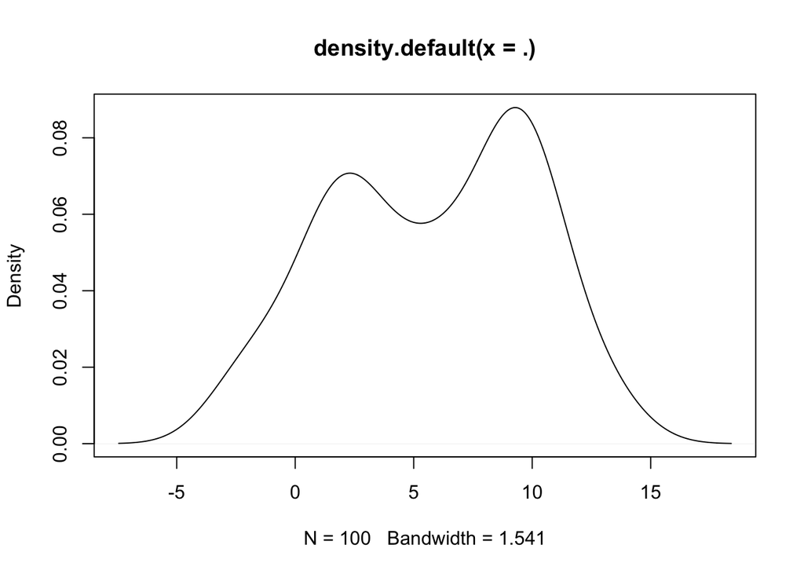

```r
y %>% density %>% plot
```

- Plot the least squares curve from values 2 to 10, conform the previous exercise

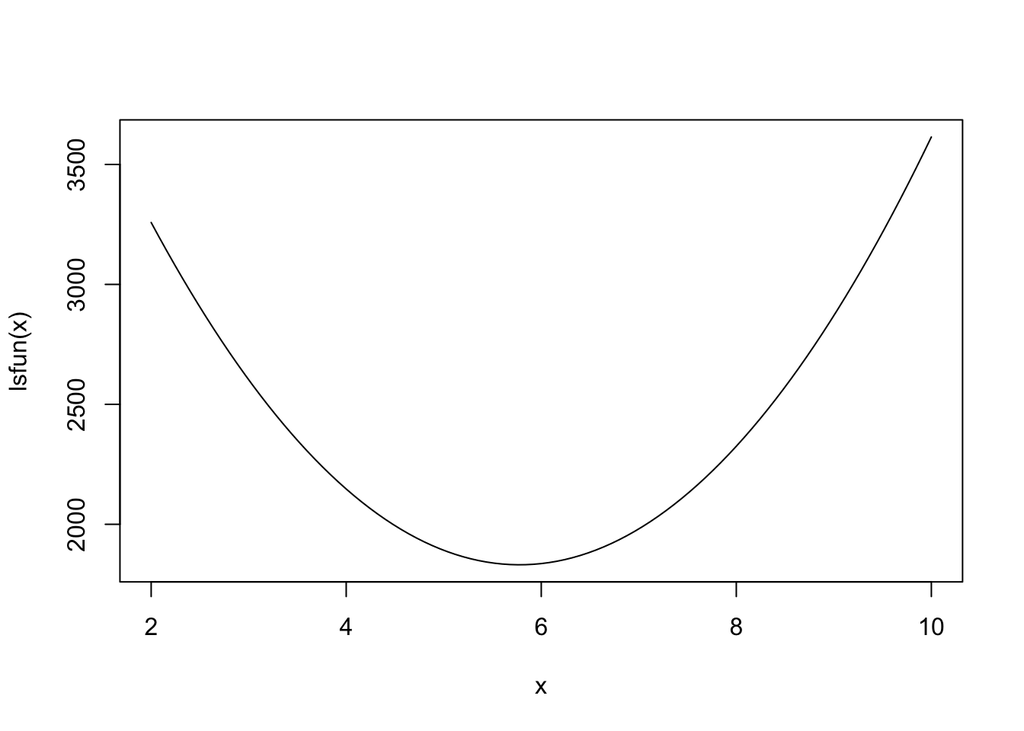

```r
lsfun <- function(meanestimate) apply(outer(y, meanestimate, "-")^2, 2, sum)
curve(lsfun, from = 2, to = 10)
```

- Plot a curve that zooms in on the minimum (i.e. the least squared deviations)

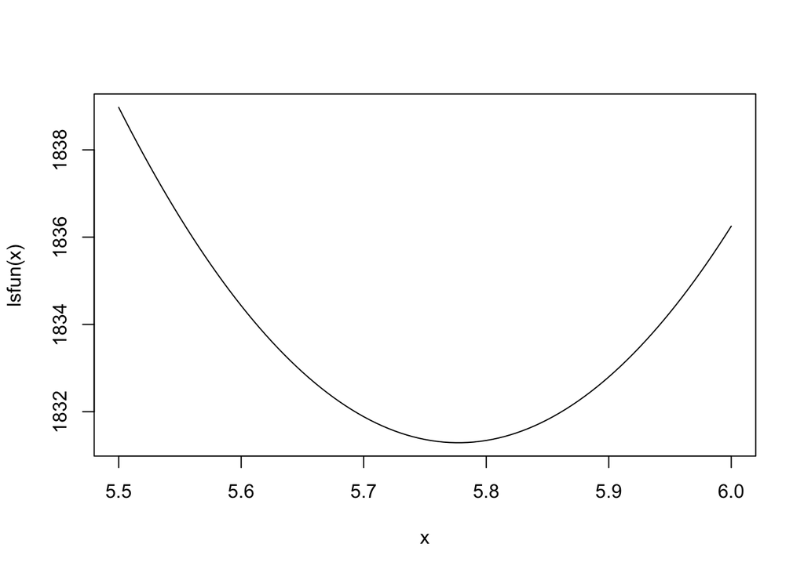

```r
curve(lsfun, from = 5.5, to = 6)
```

- Report the `meanestimate` that would minimize the least squares function

**Naturally, this is the mean of `y`, which equals 5.777224**

End of practical.

# Useful References

- [`magrittr`](https://magrittr.tidyverse.org)
- [`R` for Data Science](http://r4ds.had.co.nz) - [Chapter 18 on pipes](http://r4ds.had.co.nz/pipes.html)